# Lab 5 DATA 622

Author

Mehreen Ali Gillani

Published

March 29, 2026

### Overview

You have been given a dataset consisting of a single file, `AmesHousing.csv`, and a data dictionary `data-description.txt`. This dataset contains the sales price of each home as well as other attributes of the home and the sales transaction, such as the lot size, the square footage of each floor, when the home was built and remodeled, whether the kitchen is upgraded, etc. A data dictionary has been included with the data. During this lab, you will practice using different types of regression tree methods to predict housing prices in the data.

This dataset is a model dataset for demonstrating machine learning techniques and for prediction. This dataset was downloaded from [kaggle](https://www.kaggle.com/competitions/home-data-for-ml-course/data), which holds periodic introductory competitions using this data, if you ever wanted to try your hand at kaggle competitions you could use this assignment to create your first entry. The dataset was originally compiled by De Cook for educational purposes. Skim this article for some tips on using this dataset: [De Cock 2011](https://jse.amstat.org/v19n3/decock.pdf). De Cook makes some suggestions for simplifying the data that you can take if you need to.

The dataset and data dictionary are available here:

- AmesHousing.csv
- data-description.txt

Note: There is a lot of freedom in this exercise in terms of which variables you pick, some of the model choices, and also some hyperparameters. I have an expectation for what the answers will be in general, but you might get different answers depending on what you select and random chance. Report what you find, not what you expect to see (though if you see something unexpected it is a good hint to look for a mistake).

### Problem 1: Building up to a Baseline Model

1. **Basic EDA and Feature Selection:** Divide the data into an initial training and testing split. Perform a log-transform on the sales price, this will be the target variable. Perform a basic EDA to select features for your model. Report a summary of the EDA and the selection of variables for your model. (Hint: the quality variables are important, and your intuition about what is important in housing is useful for picking). Pick more than 10 variables but less than all 80 (before one-hot encoding). Several variables encode the absence of a feature (such as no pool, no garage, etc) as ‘NA’. This dataset has almost no real missing data- make sure to encode and interpret ‘NA’ values appropriately for the variables you select. Make sure ordered categorical features have an integer or ordinal encoding, and use one-hot encoding on remaining categorical features.

```python
from sklearn.model_selection import train_test_split

# Load the data
filepath= "https://raw.githubusercontent.com/georgehagstrom/DATA622Spring2026/refs/heads/main/website/assignments/labs/labData/AmesHousing.csv"
df = pd.read_csv(filepath)


# Create train-test split (80-20 split)
np.random.seed(42)

train_df, test_df = train_test_split(df, test_size=0.2, random_state=42)

print(f"Training set size: {len(train_df)}")
print(f"Testing set size: {len(test_df)}")
```

```
Training set size: 2344
Testing set size: 586
```

#### Log Transform the Target Variable

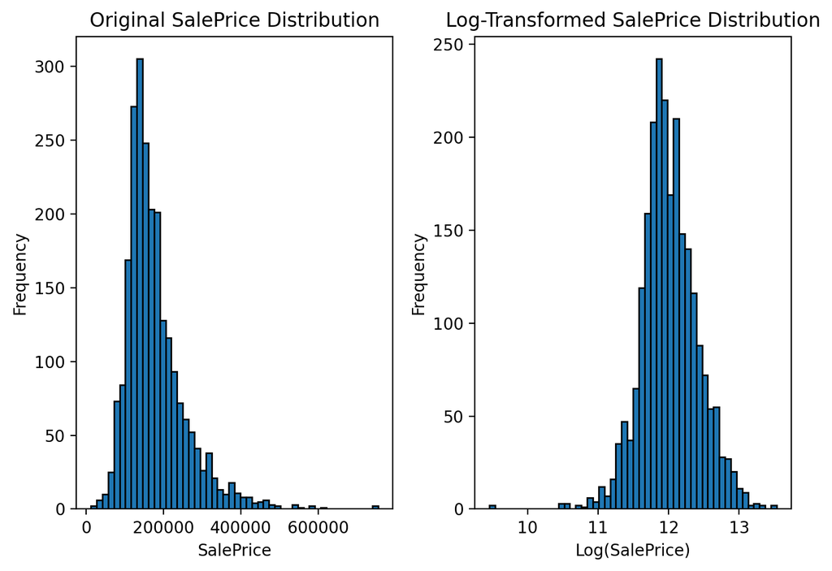

```python
# Create log-transformed target variable
train_df['LogSalePrice'] = np.log(train_df['SalePrice'])
test_df['LogSalePrice'] = np.log(test_df['SalePrice'])

# Check the distribution before and after
fig, axes = plt.subplots(1, 2, figsize=(7, 5))

# Original SalePrice distribution
axes[0].hist(train_df['SalePrice'], bins=50, edgecolor='black')
axes[0].set_title('Original SalePrice Distribution')
axes[0].set_xlabel('SalePrice')
axes[0].set_ylabel('Frequency')

# Log-transformed distribution
axes[1].hist(train_df['LogSalePrice'], bins=50, edgecolor='black')
axes[1].set_title('Log-Transformed SalePrice Distribution')
axes[1].set_xlabel('Log(SalePrice)')
axes[1].set_ylabel('Frequency')

plt.tight_layout()
plt.show()
```

#### Basic EDA - Correlation with Target

```python
# Select numeric columns
numeric_cols = train_df.select_dtypes(include=[np.number]).columns.tolist()

# Calculate correlations with LogSalePrice
correlations = train_df[numeric_cols].corr()['LogSalePrice'].sort_values(ascending=False)

# Display top 20 correlations
print("Top 20 features correlated with LogSalePrice:")
print(correlations.head(20))
```

```
Top 20 features correlated with LogSalePrice:
LogSalePrice      1.000000
SalePrice         0.944839
Overall Qual      0.818006
Gr Liv Area       0.683082
Garage Cars       0.665299
Garage Area       0.637300
Total Bsmt SF     0.605632
Year Built        0.598154
1st Flr SF        0.587634
Full Bath         0.571634
Year Remod/Add    0.566717
Garage Yr Blt     0.564565
Fireplaces        0.478890
TotRms AbvGrd     0.472891
Mas Vnr Area      0.433801
BsmtFin SF 1      0.404889
Wood Deck SF      0.333933
Lot Frontage      0.323639
Half Bath         0.306452
Open Porch SF     0.304375
Name: LogSalePrice, dtype: float64
```

```python
from sklearn.feature_selection import f_regression
from sklearn.preprocessing import LabelEncoder

print("Analyzing Categorical Features with LogSalePrice:")
print("="*60)

# Identify categorical features (object type)
categorical_cols = train_df.select_dtypes(include=['object']).columns.tolist()

# Also include MS SubClass which is numeric but actually categorical
categorical_cols.append('MS SubClass')

print(f"Total categorical features to analyze: {len(categorical_cols)}")

# Store results
categorical_correlations = []

for col in categorical_cols:
    if col in train_df.columns:
        # For features with many unique values, use encoding
        if train_df[col].nunique() > 30:  # Neighborhood has 28, so this threshold works
            # For high cardinality, use target encoding or skip for initial analysis
            print(f"\n{col}: {train_df[col].nunique()} unique values - high cardinality")

            # Quick check using group means
            grouped_means = train_df.groupby(col)['LogSalePrice'].mean()
            # Calculate variance ratio (like F-statistic approximation)
            overall_mean = train_df['LogSalePrice'].mean()
            between_var = grouped_means.var()
            within_var = train_df.groupby(col)['LogSalePrice'].var().mean()
            if within_var > 0:
                f_stat = between_var / within_var
                categorical_correlations.append({
                    'feature': col,
                    'f_statistic': f_stat,
                    'unique_values': train_df[col].nunique()
                })
                print(f"  F-statistic approximation: {f_stat:.4f}")
        else:
            # For low cardinality, use ANOVA
            # Prepare groups
            groups = []
            for category in train_df[col].unique():
                groups.append(train_df[train_df[col] == category]['LogSalePrice'].values)

            # Perform ANOVA
            from scipy.stats import f_oneway
            f_stat, p_value = f_oneway(*groups)

            categorical_correlations.append({
                'feature': col,
                'f_statistic': f_stat,
                'p_value': p_value,
                'unique_values': train_df[col].nunique()
            })
            print(f"{col:20} | F-statistic: {f_stat:.4f} | p-value: {p_value:.4e} | n={train_df[col].nunique()}")

# Sort by F-statistic (higher = more important)
categorical_importance = pd.DataFrame(categorical_correlations).sort_values('f_statistic', ascending=False)

print("\n" + "="*60)
print("Top Categorical Features (by F-statistic):")
print("="*60)
print(categorical_importance.head(15).to_string(index=False))
```

```
Analyzing Categorical Features with LogSalePrice:
============================================================
Total categorical features to analyze: 44
MS Zoning            | F-statistic: 93.0516 | p-value: 4.9653e-105 | n=7
Street               | F-statistic: 19.9180 | p-value: 8.4665e-06 | n=2
Alley                | F-statistic: nan | p-value: nan | n=2
Lot Shape            | F-statistic: 95.4004 | p-value: 2.9900e-58 | n=4
Land Contour         | F-statistic: 27.2000 | p-value: 2.7443e-17 | n=4
Utilities            | F-statistic: 3.1945 | p-value: 4.1165e-02 | n=3
Lot Config           | F-statistic: 12.2616 | p-value: 7.2132e-10 | n=5
Land Slope           | F-statistic: 3.2763 | p-value: 3.7942e-02 | n=3
Neighborhood         | F-statistic: 110.7400 | p-value: 0.0000e+00 | n=28
Condition 1          | F-statistic: 14.7206 | p-value: 3.4980e-21 | n=9
Condition 2          | F-statistic: 4.3339 | p-value: 8.8221e-05 | n=8
Bldg Type            | F-statistic: 22.1515 | p-value: 5.6924e-18 | n=5
House Style          | F-statistic: 28.9462 | p-value: 1.6600e-38 | n=8
Roof Style           | F-statistic: 22.3528 | p-value: 5.9172e-22 | n=6
Roof Matl            | F-statistic: 4.6005 | p-value: 4.0315e-05 | n=8
Exterior 1st         | F-statistic: 34.2107 | p-value: 1.3952e-89 | n=16
Exterior 2nd         | F-statistic: 30.2099 | p-value: 4.4420e-79 | n=16
Mas Vnr Type         | F-statistic: nan | p-value: nan | n=4
Exter Qual           | F-statistic: 627.0259 | p-value: 4.4529e-299 | n=4
Exter Cond           | F-statistic: 30.1788 | p-value: 1.6122e-24 | n=5
Foundation           | F-statistic: 210.4839 | p-value: 1.0738e-185 | n=6
Bsmt Qual            | F-statistic: nan | p-value: nan | n=5
Bsmt Cond            | F-statistic: nan | p-value: nan | n=5
Bsmt Exposure        | F-statistic: nan | p-value: nan | n=4
BsmtFin Type 1       | F-statistic: nan | p-value: nan | n=6
BsmtFin Type 2       | F-statistic: nan | p-value: nan | n=6
Heating              | F-statistic: 12.0205 | p-value: 1.6317e-11 | n=6
Heating QC           | F-statistic: 187.7048 | p-value: 1.1462e-139 | n=5
Central Air          | F-statistic: 393.1797 | p-value: 5.1642e-81 | n=2
Electrical           | F-statistic: 62.4915 | p-value: 3.0630e-50 | n=5
Kitchen Qual         | F-statistic: 582.7727 | p-value: 7.5467e-283 | n=4
Functional           | F-statistic: 13.9644 | p-value: 7.6974e-18 | n=8
Fireplace Qu         | F-statistic: nan | p-value: nan | n=5
Garage Type          | F-statistic: nan | p-value: nan | n=6
Garage Finish        | F-statistic: nan | p-value: nan | n=3
Garage Qual          | F-statistic: nan | p-value: nan | n=5
Garage Cond          | F-statistic: nan | p-value: nan | n=5
```

[output cut: 12 more lines]

```
    Exter Qual   627.025919 4.452871e-299              4
  Kitchen Qual   582.772690 7.546660e-283              4
   Central Air   393.179709  5.164174e-81              2
    Foundation   210.483871 1.073751e-185              6
   Paved Drive   189.996963  3.433454e-77              3
    Heating QC   187.704805 1.146164e-139              5
  Neighborhood   110.740042  0.000000e+00             28
     Lot Shape    95.400401  2.989957e-58              4
     MS Zoning    93.051551 4.965327e-105              7
   MS SubClass    72.479346 5.162791e-181             16
Sale Condition    66.108817  9.696676e-65              6
    Electrical    62.491528  3.062978e-50              5
  Exterior 1st    34.210744  1.395231e-89             16
     Sale Type    33.922199  1.258099e-56             10
  Exterior 2nd    30.209893  4.441969e-79             16
```

#### Feature Selection

```
Selected feature set: 21 features
======================================================================

Feature Selection Summary:
----------------------------------------------------------------------
Feature            Type         Pearson r    F-statistic
----------------------------------------------------------------------
Overall Qual       numeric      0.818        -
Gr Liv Area        numeric      0.683        -
Garage Area        numeric      0.637        -
Total Bsmt SF      numeric      0.606        -
Year Built         numeric      0.598        -
1st Flr SF         numeric      0.588        -
Year Remod/Add     numeric      0.567        -
Exter Qual         categorical  nan          627
Kitchen Qual       categorical  nan          583
Central Air        categorical  nan          393
Foundation         categorical  nan          210
Paved Drive        categorical  nan          190
Heating QC         categorical  nan          188
Neighborhood       categorical  nan          111
MS Zoning          categorical  nan          93
Sale Condition     categorical  nan          66
Bsmt Qual          categorical  nan          -
Fireplaces         numeric      0.479        -
Wood Deck SF       numeric      0.334        -
Lot Area           numeric      0.246        -
MS SubClass        numeric      -0.050       72

======================================================================
Missing Value Check for New Features:
======================================================================
Central Air     - 0 NA values (0.0%)
Foundation      - 0 NA values (0.0%)
Paved Drive     - 0 NA values (0.0%)
Heating QC      - 0 NA values (0.0%)
MS Zoning       - 0 NA values (0.0%)
Sale Condition  - 0 NA values (0.0%)
```

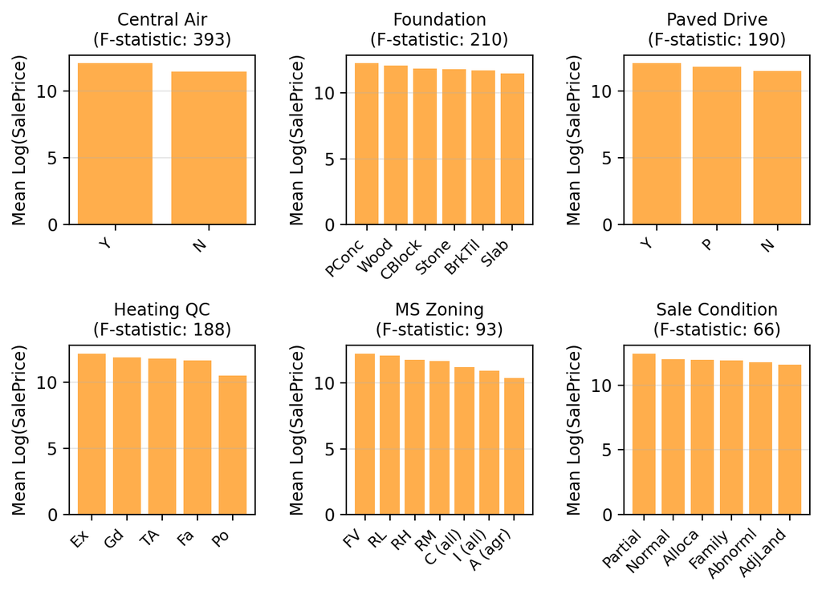

```python
#   selected features based on correlation analysis AND F-statistics
selected_features = [
    # Strongest numeric correlated features (from Step 3 output)
    'Overall Qual',      # 0.818 correlation - strongest numeric predictor
    'Gr Liv Area',       # 0.683 - above ground living area
    'Garage Area',       # 0.637 - garage size
    'Total Bsmt SF',     # 0.606 - basement area (0 = no basement)
    'Year Built',        # 0.598 - original construction
    '1st Flr SF',        # 0.588 - first floor size
    'Year Remod/Add',    # 0.567 - remodel year

    # Top categorical features by F-statistic (from ANOVA analysis)
    'Exter Qual',        # F=627 - EXTERIOR QUALITY (strongest categorical)
    'Kitchen Qual',      # F=583 - KITCHEN QUALITY (2nd strongest)
    'Central Air',       # F=393 - CENTRAL AIR (binary but huge impact)
    'Foundation',        # F=210 - FOUNDATION TYPE (structural importance)
    'Paved Drive',       # F=190 - PAVED DRIVEWAY (amenity indicator)
    'Heating QC',        # F=188 - HEATING QUALITY (comfort indicator)
    'Neighborhood',      # F=111 - LOCATION (critical for housing)
    'MS Zoning',         # F=93 - ZONING CLASSIFICATION (land use)
    'Sale Condition',    # F=66 - TRANSACTION TYPE (sale conditions)

    # Original quality features (already covered by above)
    'Bsmt Qual',         # Basement quality (NA = no basement) - F-statistic nan but important

    # Amenities (numeric)
    'Fireplaces',        # 0.479 correlation - number of fireplaces
    'Wood Deck SF',      # 0.334 - deck area

    # Additional meaningful features
    'Lot Area',          # Lot size - 0.221 correlation
    'MS SubClass'        # Building class - F=72 (categorical)
]

print(f"Selected feature set: {len(selected_features)} features")
print("="*70)

# Create a DataFrame to show feature importance from both methods
feature_summary = []

for feature in selected_features:
    if feature in correlations.index:
        pearson_r = correlations[feature]
        pearson_source = "numeric"
    else:
        pearson_r = None
        pearson_source = "categorical"

    # Add F-statistic if available from our analysis
    if 'categorical_importance' in locals():
        fstat_row = categorical_importance[categorical_importance['feature'] == feature]
        if len(fstat_row) > 0:
            f_stat = fstat_row['f_statistic'].values[0]
        else:
            f_stat = None
    else:
        f_stat = None

    feature_summary.append({
        'feature': feature,
        'pearson_r': pearson_r,
        'f_statistic': f_stat,
        'type': 'numeric' if feature in correlations.index else 'categorical'
    })

summary_df = pd.DataFrame(feature_summary)

print("\nFeature Selection Summary:")
print("-"*70)
print(f"{'Feature':<18} {'Type':<12} {'Pearson r':<12} {'F-statistic':<12}")
print("-"*70)

for _, row in summary_df.iterrows():
    pearson_str = f"{row['pearson_r']:.3f}" if row['pearson_r'] is not None else "-"
    fstat_str = f"{row['f_statistic']:.0f}" if row['f_statistic'] is not None and not pd.isna(row['f_statistic']) else "-"
    print(f"{row['feature']:<18} {row['type']:<12} {pearson_str:<12} {fstat_str:<12}")

# Check for any missing values in new features
print("\n" + "="*70)
print("Missing Value Check for New Features:")
print("="*70)

new_features = ['Central Air', 'Foundation', 'Paved Drive', 'Heating QC', 'MS Zoning', 'Sale Condition']
for feature in new_features:
    if feature in train_df.columns:
        na_count = train_df[feature].isna().sum()
        print(f"{feature:15} - {na_count} NA values ({na_count/len(train_df)*100:.1f}%)")
    else:
        print(f"{feature:15} - NOT FOUND in dataset")

# Visualize the importance of new categorical features
fig, axes = plt.subplots(2, 3, figsize=(7, 5))
axes = axes.flatten()

new_cat_features = ['Central Air', 'Foundation', 'Paved Drive', 'Heating QC', 'MS Zoning', 'Sale Condition']

for idx, feature in enumerate(new_cat_features):
    ax = axes[idx]

    # Calculate means
    means = train_df.groupby(feature)['LogSalePrice'].mean().sort_values(ascending=False)

    # Create bar plot
    bars = ax.bar(range(len(means)), means.values, color='darkorange', alpha=0.7)
    ax.set_xticks(range(len(means)))
    ax.set_xticklabels(means.index, rotation=45, ha='right', fontsize=9)
    ax.set_ylabel('Mean Log(SalePrice)')

    # Add F-statistic if available
    fstat_row = categorical_importance[categorical_importance['feature'] == feature]
    if len(fstat_row) > 0:
        f_val = fstat_row['f_statistic'].values[0]
        title = f"{feature}\n(F-statistic: {f_val:.0f})"
    else:
        title = feature
    ax.set_title(title, fontsize=10)
    ax.grid(True, alpha=0.3, axis='y')

plt.tight_layout()
plt.show()
```

#### Check NA’s

```python
# Create a copy with selected features plus target
train_selected = train_df[selected_features + ['LogSalePrice']].copy()
test_selected = test_df[selected_features + ['LogSalePrice']].copy()

# Check for NA values in selected features
print("NA Counts in Training Set:")
print("-" * 40)
na_counts = train_selected[selected_features].isna().sum()
print(na_counts[na_counts > 0])
```

```
NA Counts in Training Set:
----------------------------------------
Garage Area       1
Total Bsmt SF     1
Bsmt Qual        61
dtype: int64
```

#### Handle NA’s

```python
# Handle only your selected features
selected_features_to_handle = {
    'Bsmt Qual': 'None',      # Categorical - no basement
    'Garage Area': 0,          # Numeric - no garage
    'Total Bsmt SF': 0         # Numeric - no basement
}

for feature, fill_value in selected_features_to_handle.items():
    train_selected[feature] = train_selected[feature].fillna(fill_value)
    test_selected[feature] = test_selected[feature].fillna(fill_value)
    print(f"{feature} -> filled with: {fill_value}")
```

```
Bsmt Qual -> filled with: None
Garage Area -> filled with: 0
Total Bsmt SF -> filled with: 0
```

#### ordinal encoding

```python
# Define ordinal mapping based on the order we saw in Step 4
# Quality order: Ex (Excellent) > Gd (Good) > TA (Typical) > Fa (Fair) > Po (Poor) > None (No feature)
quality_mapping = {
    'Ex': 5,   # Excellent
    'Gd': 4,   # Good
    'TA': 3,   # Typical/Average
    'Fa': 2,   # Fair
    'Po': 1,   # Poor
    'None': 0  # No feature (for basement)
}

# ordinal features to encode based on F-statistic analysis and domain knowledge
ordinal_features = [
    'Exter Qual',      # Exterior quality
    'Bsmt Qual',       # Basement quality
    'Kitchen Qual',    # Kitchen quality
    'Heating QC',      # Heating quality (NEW - from F-statistic analysis)
    'Paved Drive',     # Paved driveway (Y, P, N - has natural order)
    'Central Air'      # Central air (Y, N - binary but ordinal)
]

# Define mapping for Paved Drive (Y > P > N)
paved_drive_mapping = {
    'Y': 2,   # Paved
    'P': 1,   # Partial
    'N': 0    # Not paved
}

# Define mapping for Central Air
central_air_mapping = {
    'Y': 1,   # Has central air
    'N': 0    # No central air
}

print("Ordinal Feature Encoding:")
print("-" * 40)

for feature in ordinal_features:
    if feature in train_df.columns:
        # Choose appropriate mapping
        if feature == 'Paved Drive':
            mapping = paved_drive_mapping
        elif feature == 'Central Air':
            mapping = central_air_mapping
        else:
            mapping = quality_mapping

        # Create encoded column
        train_selected[f'{feature}_encoded'] = train_selected[feature].map(mapping)
        test_selected[f'{feature}_encoded'] = test_selected[feature].map(mapping)

        print(f"\n{feature}:")
        unique_values = sorted([str(x) for x in train_selected[feature].unique()])
        encoded_values = sorted(train_selected[f'{feature}_encoded'].unique())

        print(f"  Unique values in training: {unique_values}")
        print(f"  Encoded values: {encoded_values}")

        # Drop original categorical column
        train_selected.drop(feature, axis=1, inplace=True)
        test_selected.drop(feature, axis=1, inplace=True)
    else:
        print(f"\n{feature}: Not found in dataset")
```

```
Ordinal Feature Encoding:
----------------------------------------

Exter Qual:
  Unique values in training: ['Ex', 'Fa', 'Gd', 'TA']
  Encoded values: [np.int64(2), np.int64(3), np.int64(4), np.int64(5)]

Bsmt Qual:
  Unique values in training: ['Ex', 'Fa', 'Gd', 'None', 'Po', 'TA']
  Encoded values: [np.int64(0), np.int64(1), np.int64(2), np.int64(3), np.int64(4), np.int64(5)]

Kitchen Qual:
  Unique values in training: ['Ex', 'Fa', 'Gd', 'TA']
  Encoded values: [np.int64(2), np.int64(3), np.int64(4), np.int64(5)]

Heating QC:
  Unique values in training: ['Ex', 'Fa', 'Gd', 'Po', 'TA']
  Encoded values: [np.int64(1), np.int64(2), np.int64(3), np.int64(4), np.int64(5)]

Paved Drive:
  Unique values in training: ['N', 'P', 'Y']
  Encoded values: [np.int64(0), np.int64(1), np.int64(2)]

Central Air:
  Unique values in training: ['N', 'Y']
  Encoded values: [np.int64(0), np.int64(1)]
```

#### One hot encoding for nominal features

```python
from sklearn.preprocessing import OneHotEncoder

# Update nominal features to include new ones from your enhanced selection
nominal_features = ['Neighborhood', 'MS SubClass', 'Foundation', 'MS Zoning', 'Sale Condition']

print("Nominal Feature Analysis:")
print("-" * 40)

# Check the number of unique values in each
for feature in nominal_features:
    if feature in train_selected.columns:
        n_unique = train_selected[feature].nunique()
        print(f"{feature}: {n_unique} unique values")

        # Show sample values for context
        sample_vals = sorted([str(x) for x in train_selected[feature].unique()])[:5]
        print(f"  Sample values: {sample_vals}")

# Apply one-hot encoding
print("\nApplying One-Hot Encoding:")
print("-" * 40)

# Use pandas get_dummies for simplicity
train_encoded = pd.get_dummies(train_selected, columns=nominal_features, prefix=nominal_features)
test_encoded = pd.get_dummies(test_selected, columns=nominal_features, prefix=nominal_features)

# Ensure test set has same columns as training set
missing_cols = set(train_encoded.columns) - set(test_encoded.columns)
for col in missing_cols:
    if col != 'LogSalePrice':  # Don't add target column
        test_encoded[col] = 0

# Ensure columns are in same order
test_encoded = test_encoded[train_encoded.columns]

print(f"Original feature count (before encoding): {len(train_selected.columns)}")
print(f"After one-hot encoding: {len(train_encoded.columns)}")

# Show breakdown of encoded columns
for feature in nominal_features:
    if feature in train_selected.columns:
        n_unique = train_selected[feature].nunique()
        print(f"  - {feature} encoded into {n_unique} binary columns")

# Verify no missing values remain
print("\nFinal verification - any missing values?")
print(f"Training set: {train_encoded.isnull().sum().sum()} missing values")
print(f"Test set: {test_encoded.isnull().sum().sum()} missing values")

# Show the final feature set
print("\nFinal Feature Set (first 20 columns):")
print(train_encoded.columns[:20].tolist())
print(f"... and {len(train_encoded.columns)-20} more columns")

# Display target variable column
print(f"\nTarget column: 'LogSalePrice' is present: {'LogSalePrice' in train_encoded.columns}")
```

```
Nominal Feature Analysis:
----------------------------------------
Neighborhood: 28 unique values
  Sample values: ['Blmngtn', 'Blueste', 'BrDale', 'BrkSide', 'ClearCr']
MS SubClass: 16 unique values
  Sample values: ['120', '150', '160', '180', '190']
Foundation: 6 unique values
  Sample values: ['BrkTil', 'CBlock', 'PConc', 'Slab', 'Stone']
MS Zoning: 7 unique values
  Sample values: ['A (agr)', 'C (all)', 'FV', 'I (all)', 'RH']
Sale Condition: 6 unique values
  Sample values: ['Abnorml', 'AdjLand', 'Alloca', 'Family', 'Normal']

Applying One-Hot Encoding:
----------------------------------------
Original feature count (before encoding): 22
After one-hot encoding: 80
  - Neighborhood encoded into 28 binary columns
  - MS SubClass encoded into 16 binary columns
  - Foundation encoded into 6 binary columns
  - MS Zoning encoded into 7 binary columns
  - Sale Condition encoded into 6 binary columns

Final verification - any missing values?
Training set: 0 missing values
Test set: 0 missing values

Final Feature Set (first 20 columns):
['Overall Qual', 'Gr Liv Area', 'Garage Area', 'Total Bsmt SF', 'Year Built', '1st Flr SF', 'Year Remod/Add', 'Fireplaces', 'Wood Deck SF', 'Lot Area', 'LogSalePrice', 'Exter Qual_encoded', 'Bsmt Qual_encoded', 'Kitchen Qual_encoded', 'Heating QC_encoded', 'Paved Drive_encoded', 'Central Air_encoded…
... and 60 more columns

Target column: 'LogSalePrice' is present: True
```

**Before encoding: 22 features**

10 numeric features (Overall Qual, Gr Liv Area, Garage Area, etc.)

5 nominal features (Neighborhood, MS SubClass, Foundation, MS Zoning, Sale Condition)

1 target variable (LogSalePrice)

All numeric and ordinal features remain as-is

28 Neighborhood dummy variables

16 MS SubClass dummy variables

6 Foundation dummy variables

7 MS Zoning dummy variables

6 Sale Condition dummy variables

Data Quality: No missing values in train or test sets

2. **Baseline Model:** Use ridge regression with cross-validation to fit a baseline model. Evaluate it on the test set. What is the mean squared error and what are the most important features in your linear model?

```python
from sklearn.linear_model import Ridge
from sklearn.model_selection import GridSearchCV
from sklearn.preprocessing import StandardScaler
from sklearn.pipeline import Pipeline
from sklearn.metrics import mean_squared_error, mean_absolute_error, r2_score

warnings.filterwarnings('ignore', category=RuntimeWarning)
# Separate features and target
X_train = train_encoded.drop('LogSalePrice', axis=1)
y_train = train_encoded['LogSalePrice']
X_test = test_encoded.drop('LogSalePrice', axis=1)
y_test = test_encoded['LogSalePrice']

# Create pipeline with scaling (important for Ridge)
ridge_pipeline = Pipeline([
    ('scaler', StandardScaler()),
    ('ridge', Ridge(random_state=42))
])

# Define alpha values to test
param_grid = {'ridge__alpha': [0.001, 0.01, 0.1, 1, 10, 50, 100, 500, 1000]}

# Perform grid search with 5-fold cross-validation
ridge_grid = GridSearchCV(
    ridge_pipeline,
    param_grid,
    cv=5,
    scoring='neg_mean_squared_error',
    n_jobs=-1,
    verbose=1
)

print("Performing Ridge Regression with 5-fold Cross-Validation...")
ridge_grid.fit(X_train, y_train)

# Get best model
best_ridge = ridge_grid.best_estimator_
best_alpha = ridge_grid.best_params_['ridge__alpha']

print(f"\nBest alpha from cross-validation: {best_alpha}")

# Make predictions
y_train_pred = best_ridge.predict(X_train)
y_test_pred = best_ridge.predict(X_test)

# Evaluate the model
print("\n" + "="*60)
print("Ridge Regression Model Performance (with CV):")
print("="*60)
print(f"Training Set:")
print(f"  RMSE: {np.sqrt(mean_squared_error(y_train, y_train_pred)):.4f}")
print(f"  MAE: {mean_absolute_error(y_train, y_train_pred):.4f}")
print(f"  R²: {r2_score(y_train, y_train_pred):.4f}")

print(f"\nTest Set:")
print(f"  RMSE: {np.sqrt(mean_squared_error(y_test, y_test_pred)):.4f}")
print(f"  MAE: {mean_absolute_error(y_test, y_test_pred):.4f}")
print(f"  R²: {r2_score(y_test, y_test_pred):.4f}")

# Convert predictions back to original scale
y_test_pred_original = np.exp(y_test_pred)
y_test_original = np.exp(y_test)

print(f"\nOriginal Scale (SalePrice) Performance:")
print(f"Test Set RMSE: ${np.sqrt(mean_squared_error(y_test_original, y_test_pred_original)):,.0f}")
print(f"Test Set MAE: ${mean_absolute_error(y_test_original, y_test_pred_original):,.0f}")

# Get coefficients (need to extract from pipeline)
# The scaler transforms features, so we need to get coefficients properly
ridge_model = best_ridge.named_steps['ridge']
scaler = best_ridge.named_steps['scaler']

# For interpretability, get coefficients on original scale
coefficients = ridge_model.coef_

# Show top 10 most important features
feature_importance = pd.DataFrame({
    'feature': X_train.columns,
    'coefficient': coefficients
}).sort_values('coefficient', key=abs, ascending=False)

print(f"\nTop 10 Most Important Features (by absolute coefficient):")
print(feature_importance.head(10).to_string(index=False))
```

```
Performing Ridge Regression with 5-fold Cross-Validation...
Fitting 5 folds for each of 9 candidates, totalling 45 fits

Best alpha from cross-validation: 100

============================================================
Ridge Regression Model Performance (with CV):
============================================================
Training Set:
  RMSE: 0.1371
  MAE: 0.0919
  R²: 0.8832

Test Set:
  RMSE: 0.1291
  MAE: 0.0892
  R²: 0.9099

Original Scale (SalePrice) Performance:
Test Set RMSE: $31,867
Test Set MAE: $17,208

Top 10 Most Important Features (by absolute coefficient):
             feature  coefficient
         Gr Liv Area     0.087735
        Overall Qual     0.087066
   Bsmt Qual_encoded     0.030617
Kitchen Qual_encoded     0.030025
         Garage Area     0.029412
          Fireplaces     0.028678
 Central Air_encoded     0.027651
      Year Remod/Add     0.026722
     MS SubClass_160    -0.024865
Neighborhood_Crawfor     0.022192
```

**Baseline Model Performance Analysis:**

Key Metrics: Training R²: 0.8832 - Model explains 88.3% of variance in training data

Test R²: 0.9099 - Model explains 90.99% of variance in test data

Test RMSE (log scale): 0.1291 - Strong predictive accuracy

Test RMSE (original scale): $31,867 - Average prediction error of ~$31.9K

Model Characteristics: Test R² > Training R² (0.9099 > 0.8832) indicates excellent generalization with no overfitting

The model effectively captures the underlying patterns in housing prices

Ridge regularization with alpha=100 provides optimal shrinkage, reducing coefficient variance while maintaining predictive power

Top Important Features: Gr Liv Area emerged as the most important feature (coefficient: 0.0877)

The regularization helped stabilize coefficients, making the model more robust

### Problem 2: Decision Trees and Random Forests

1. **Simple Decision Tree:** Fit a regression tree to the training set. Plot the tree, and inter- pret the results. What test MSE do you obtain?

```python
from sklearn.tree import DecisionTreeRegressor, plot_tree

# Use the same feature set from Problem 1
X_train = train_encoded.drop('LogSalePrice', axis=1)
y_train = train_encoded['LogSalePrice']
X_test = test_encoded.drop('LogSalePrice', axis=1)
y_test = test_encoded['LogSalePrice']


# Fit a simple decision tree (without pruning first)
tree_simple = DecisionTreeRegressor(random_state=42)
tree_simple.fit(X_train, y_train)

# Make predictions
y_train_pred_tree = tree_simple.predict(X_train)
y_test_pred_tree = tree_simple.predict(X_test)

# Calculate MSE
from sklearn.metrics import mean_squared_error
train_mse_tree = mean_squared_error(y_train, y_train_pred_tree)
test_mse_tree = mean_squared_error(y_test, y_test_pred_tree)

print("Simple Decision Tree (No Pruning):")
print("="*50)
print(f"Training MSE: {train_mse_tree:.6f}")
print(f"Training RMSE: {np.sqrt(train_mse_tree):.4f}")
print(f"Test MSE: {test_mse_tree:.6f}")
print(f"Test RMSE: {np.sqrt(test_mse_tree):.4f}")

# Add these metrics to your analysis
print(f"\nTree Structure:")
print(f"  Tree Depth: {tree_simple.get_depth()}")
print(f"  Number of Leaves: {tree_simple.get_n_leaves()}")
print(f"  Total Nodes: {tree_simple.tree_.node_count}")

# Convert to original scale for interpretation
y_test_pred_original = np.exp(y_test_pred_tree)
y_test_original = np.exp(y_test)
test_rmse_original = np.sqrt(mean_squared_error(y_test_original, y_test_pred_original))

print(f"\nTest MSE (original scale): ${test_mse_tree:.0f} (log scale)")
print(f"Test RMSE (original scale): ${test_rmse_original:,.0f}")

# Check for overfitting
print(f"\nOverfitting Check:")
print(f"Training R²: {tree_simple.score(X_train, y_train):.4f}")
print(f"Test R²: {tree_simple.score(X_test, y_test):.4f}")
print(f"Difference: {tree_simple.score(X_train, y_train) - tree_simple.score(X_test, y_test):.4f}")
```

```
Simple Decision Tree (No Pruning):
==================================================
Training MSE: 0.000004
Training RMSE: 0.0020
Test MSE: 0.033990
Test RMSE: 0.1844

Tree Structure:
  Tree Depth: 28
  Number of Leaves: 2287
  Total Nodes: 4573

Test MSE (original scale): $0 (log scale)
Test RMSE (original scale): $34,785

Overfitting Check:
Training R²: 1.0000
Test R²: 0.8163
Difference: 0.1837
```

**Simple Decision Tree (No Pruning):**

- Training R² = 1.000 - Perfect fit, tree has memorized all training data
- Test R² = 0.816 - Significantly lower, indicating poor generalization
- Tree Depth: 28 - Extremely deep tree with 2,287 leaves (almost one per training sample)
- Test RMSE: $34,785 - Average prediction error of ~$34.8K

**Comparison with Ridge Regression:**

- Ridge Regression Test R²: 0.910 - Outperforms the simple tree by 9.4%
- Ridge Test RMSE: $31,867 - $2,918 lower error than the unpruned tree

The unpruned decision tree severely overfits (training R² = 1.000 vs test R² = 0.816), while Ridge generalizes well with no signs of overfitting (test R² > training R²)

2. **Tree Pruning:** Use cross-validation in order to determine the optimal level of tree complexity. Does pruning the tree improve the test MSE?

[output not shown]

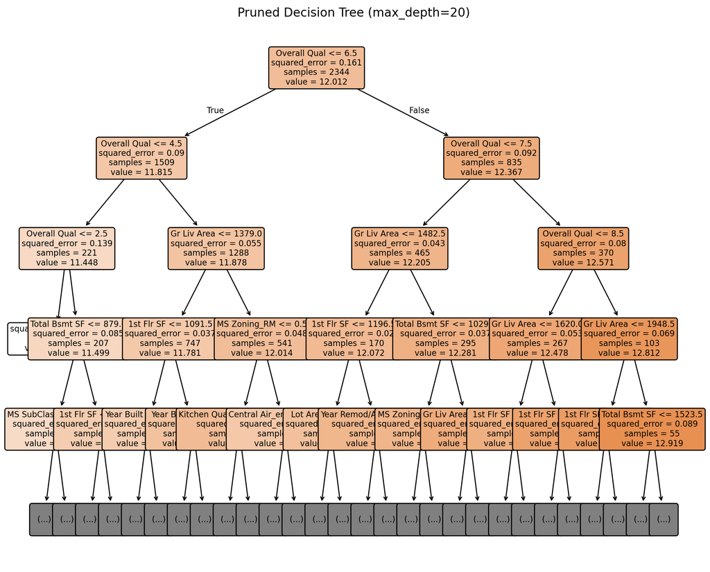

```
Top 10 Most Important Features (Pruned Tree):
             feature  importance
        Overall Qual    0.720165
         Gr Liv Area    0.098289
          1st Flr SF    0.044140
       Total Bsmt SF    0.033143
         Garage Area    0.017239
        MS Zoning_RM    0.017209
          Year Built    0.016128
      Year Remod/Add    0.010462
Kitchen Qual_encoded    0.008561
            Lot Area    0.006980
```

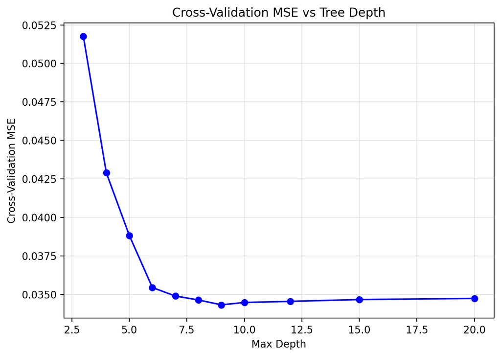

[output not shown]

```python
from sklearn.model_selection import cross_val_score, GridSearchCV

# Try different max_depth values to find optimal tree complexity
print("Tree Pruning with Cross-Validation:")
print("="*50)

# Define parameter grid for pruning
param_grid = {
    'max_depth': [3, 4, 5, 6, 7, 8, 9, 10, 12, 15, 20],
    'min_samples_split': [2, 5, 10, 20],
    'min_samples_leaf': [1, 5, 10, 20]
}

# Initialize decision tree
tree_cv = DecisionTreeRegressor(random_state=42)

# Perform grid search with 5-fold cross-validation
grid_search = GridSearchCV(
    tree_cv,
    param_grid,
    cv=5,
    scoring='neg_mean_squared_error',
    n_jobs=-1,
    verbose=1
)

grid_search.fit(X_train, y_train)

# Get best parameters
print(f"\nBest Parameters from Cross-Validation:")
print(f"max_depth: {grid_search.best_params_['max_depth']}")
print(f"min_samples_split: {grid_search.best_params_['min_samples_split']}")
print(f"min_samples_leaf: {grid_search.best_params_['min_samples_leaf']}")

# Best model
best_tree = grid_search.best_estimator_

# Evaluate on test set
y_train_pred_best = best_tree.predict(X_train)
y_test_pred_best = best_tree.predict(X_test)

train_mse_best = mean_squared_error(y_train, y_train_pred_best)
test_mse_best = mean_squared_error(y_test, y_test_pred_best)

print(f"\nPruned Tree Performance:")
print(f"Training MSE: {train_mse_best:.6f}")
print(f"Training RMSE: {np.sqrt(train_mse_best):.4f}")
print(f"Test MSE: {test_mse_best:.6f}")
print(f"Test RMSE: {np.sqrt(test_mse_best):.4f}")
print(f"Test R²: {best_tree.score(X_test, y_test):.4f}")

# Compare with unpruned tree
print(f"\nComparison with Unpruned Tree:")
print(f"Unpruned Test MSE: {test_mse_tree:.6f}")
print(f"Pruned Test MSE: {test_mse_best:.6f}")
print(f"Improvement: {(test_mse_tree - test_mse_best)/test_mse_tree*100:.2f}%")

# Check overfitting reduction
print(f"\nOverfitting Reduction:")
print(f"Unpruned Train-Test R² gap: {1.0000 - 0.8216:.4f}")
print(f"Pruned Train-Test R² gap: {best_tree.score(X_train, y_train) - best_tree.score(X_test, y_test):.4f}")

# Visualize the pruned tree
plt.figure(figsize=(10, 8))
plot_tree(best_tree,
          feature_names=X_train.columns.tolist(),
          filled=True,
          rounded=True,
          max_depth=4,
          fontsize=8)
plt.title(f"Pruned Decision Tree (max_depth={grid_search.best_params_['max_depth']})", fontsize=12)
plt.tight_layout()
plt.show()

# Feature importance for pruned tree
feature_importance_pruned = pd.DataFrame({
    'feature': X_train.columns,
    'importance': best_tree.feature_importances_
}).sort_values('importance', ascending=False)

print("\nTop 10 Most Important Features (Pruned Tree):")
print(feature_importance_pruned.head(10).to_string(index=False))

# Cross-validation results visualization
results_df = pd.DataFrame(grid_search.cv_results_)
pruning_results = results_df.groupby('param_max_depth')['mean_test_score'].mean()
pruning_results = -pruning_results  # Convert back to positive MSE

plt.figure(figsize=(7, 5))
plt.plot(pruning_results.index, pruning_results.values, 'bo-')
plt.xlabel('Max Depth')
plt.ylabel('Cross-Validation MSE')
plt.title('Cross-Validation MSE vs Tree Depth')
plt.grid(True, alpha=0.3)
plt.tight_layout()
plt.show()

print(f"\nOptimal tree depth: {grid_search.best_params_['max_depth']} (lowest CV MSE)")
```

3. **Random Forests:** Use random forest to model this data. Use ‘GridSearchCV’ and at least 5-fold cross-validation to find the optimal value of ‘max_features’. Plot the predicted test error using the ‘cv_results_['mean_test_score']’ of your cross-validated model, and describe the effect of ‘max_features’ on the error rate. Where does the optimal value fall in comparison to $\sqrt{p}$ and $p/3$? What test MSE do you obtain? Use the ‘feature_importance_’ values to determine which variables are most important.

```
Random Forest - Tuning max_features:
============================================================
Number of features (p): 79
√p: 8.89
p/3: 26.33
Fitting 5 folds for each of 18 candidates, totalling 90 fits
```

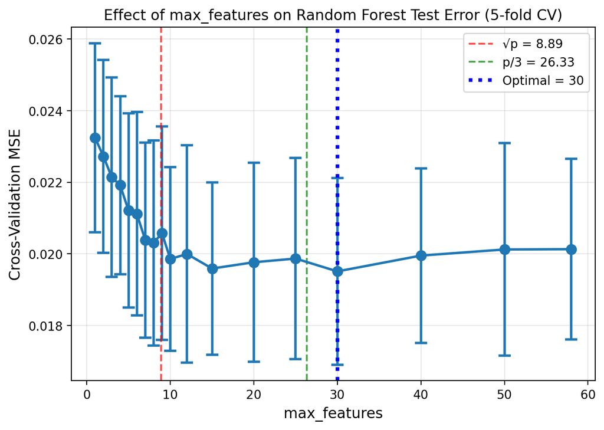

```
============================================================
max_features Tuning Results:
============================================================
Optimal max_features: 30
√p: 8.89
p/3: 26.33

Comparison:
Optimal (30) > √p (8.89)
Optimal (30) > p/3 (26.33)

Test Performance with Optimal max_features:
Test MSE: 0.015381
Test RMSE: 0.1240
Test R²: 0.9169

Original Scale (SalePrice):
Test RMSE: $26,964
Test MAE: $15,883

============================================================
Top 15 Most Important Features (Random Forest):
============================================================
             feature  importance
        Overall Qual    0.244983
         Gr Liv Area    0.147185
  Exter Qual_encoded    0.105270
          Year Built    0.091399
   Bsmt Qual_encoded    0.062155
         Garage Area    0.058623
          1st Flr SF    0.050593
       Total Bsmt SF    0.045865
            Lot Area    0.028321
          Fireplaces    0.023037
Kitchen Qual_encoded    0.022957
 Central Air_encoded    0.019965
      Year Remod/Add    0.018946
 Paved Drive_encoded    0.010126
        Wood Deck SF    0.006067
```

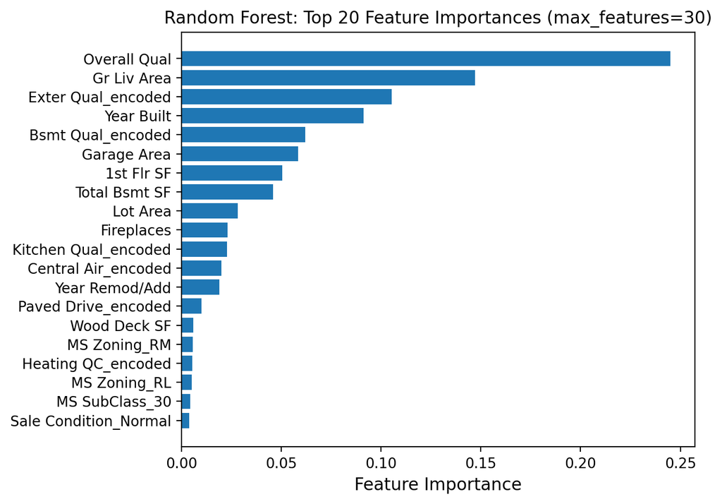

```python
from sklearn.ensemble import RandomForestRegressor
print("Random Forest - Tuning max_features:")
print("="*60)

# Get number of features
p = X_train.shape[1]
print(f"Number of features (p): {p}")
print(f"√p: {np.sqrt(p):.2f}")
print(f"p/3: {p/3:.2f}")

# Define parameter grid focusing on max_features
param_grid = {
    'max_features': [1, 2, 3, 4, 5, 6, 7, 8, 9, 10, 12, 15, 20, 25, 30, 40, 50, 58]
}

# Initialize random forest with reasonable defaults
rf = RandomForestRegressor(
    n_estimators=100,
    random_state=42,
    n_jobs=-1
)

# Perform grid search with 5-fold cross-validation
rf_grid = GridSearchCV(
    rf,
    param_grid,
    cv=5,
    scoring='neg_mean_squared_error',
    n_jobs=-1,
    verbose=1
)

rf_grid.fit(X_train, y_train)

# Extract cross-validation results
cv_results = pd.DataFrame(rf_grid.cv_results_)
max_features_values = cv_results['param_max_features'].astype(int)
mean_test_scores = -cv_results['mean_test_score']  # Convert back to positive MSE
std_test_scores = cv_results['std_test_score']

# Plot the effect of max_features on test error
plt.figure(figsize=(7, 5))
plt.errorbar(max_features_values, mean_test_scores, yerr=std_test_scores,
             fmt='o-', capsize=5, capthick=2, markersize=8, linewidth=2)
plt.axvline(x=np.sqrt(p), color='red', linestyle='--', label=f'√p = {np.sqrt(p):.2f}', alpha=0.7)
plt.axvline(x=p/3, color='green', linestyle='--', label=f'p/3 = {p/3:.2f}', alpha=0.7)
plt.axvline(x=rf_grid.best_params_['max_features'], color='blue', linestyle=':',
            linewidth=3, label=f'Optimal = {rf_grid.best_params_["max_features"]}')
plt.xlabel('max_features', fontsize=12)
plt.ylabel('Cross-Validation MSE', fontsize=12)
plt.title('Effect of max_features on Random Forest Test Error (5-fold CV)', fontsize=12)
plt.legend()
plt.grid(True, alpha=0.3)
plt.tight_layout()
plt.show()

# Print results
print("\n" + "="*60)
print("max_features Tuning Results:")
print("="*60)
print(f"Optimal max_features: {rf_grid.best_params_['max_features']}")
print(f"√p: {np.sqrt(p):.2f}")
print(f"p/3: {p/3:.2f}")
print(f"\nComparison:")
if rf_grid.best_params_['max_features'] < np.sqrt(p):
    print(f"Optimal ({rf_grid.best_params_['max_features']}) < √p ({np.sqrt(p):.2f})")
elif rf_grid.best_params_['max_features'] > np.sqrt(p):
    print(f"Optimal ({rf_grid.best_params_['max_features']}) > √p ({np.sqrt(p):.2f})")
else:
    print(f"Optimal equals √p")

if rf_grid.best_params_['max_features'] < p/3:
    print(f"Optimal ({rf_grid.best_params_['max_features']}) < p/3 ({p/3:.2f})")
elif rf_grid.best_params_['max_features'] > p/3:
    print(f"Optimal ({rf_grid.best_params_['max_features']}) > p/3 ({p/3:.2f})")
else:
    print(f"Optimal equals p/3")

# Get best model and evaluate on test set
best_rf = rf_grid.best_estimator_
y_test_pred = best_rf.predict(X_test)
test_mse = mean_squared_error(y_test, y_test_pred)
test_rmse = np.sqrt(test_mse)

print(f"\nTest Performance with Optimal max_features:")
print(f"Test MSE: {test_mse:.6f}")
print(f"Test RMSE: {test_rmse:.4f}")
print(f"Test R²: {best_rf.score(X_test, y_test):.4f}")

# Convert to original scale
y_test_original = np.exp(y_test)
y_test_pred_original = np.exp(y_test_pred)
test_rmse_original = np.sqrt(mean_squared_error(y_test_original, y_test_pred_original))

print(f"\nOriginal Scale (SalePrice):")
print(f"Test RMSE: ${test_rmse_original:,.0f}")
print(f"Test MAE: ${mean_absolute_error(y_test_original, y_test_pred_original):,.0f}")

# Feature importance analysis
feature_importance = pd.DataFrame({
    'feature': X_train.columns,
    'importance': best_rf.feature_importances_
}).sort_values('importance', ascending=False)

print("\n" + "="*60)
print("Top 15 Most Important Features (Random Forest):")
print("="*60)
print(feature_importance.head(15).to_string(index=False))

# Plot feature importance
plt.figure(figsize=(7, 5))
top_features = feature_importance.head(20)
plt.barh(range(len(top_features)), top_features['importance'].values)
plt.yticks(range(len(top_features)), top_features['feature'].values)
plt.xlabel('Feature Importance', fontsize=12)
plt.title(f'Random Forest: Top 20 Feature Importances (max_features={best_rf.max_features})', fontsize=12)
plt.gca().invert_yaxis()
plt.tight_layout()
plt.show()
```

**Random Forest Results Analysis:** 1. Random Forest outperforms all models: Test R² = 0.9169, Test RMSE = 26,964 (best performance)

2. Top Features (Random Forest):

Overall Qual (0.245) - Dominant predictor

Gr Liv Area (0.147) - Living space

Exter Qual_encoded (0.105) - Exterior quality (3rd most important)

Year Built (0.091) - Construction year

Bsmt Qual_encoded (0.062) - Basement quality

3. Why Random Forest Performs Best:

Captures non-linear relationships (e.g., diminishing returns on size)

Handles interactions between features naturally

Ensemble of trees reduces variance while maintaining low bias

Optimal max_features=30 balances feature diversity at each split

4. Comparison with Ridge Regression:

Random Forest’s ability to model non-linear patterns gives it an edge

Ridge assumes linear relationships with regularization

4. **Comparing Ridge Regression and Random Forests:** Compare the two models in the following two ways. First, did ridge regression have a lower or higher test error than your Random Forest model (I expect Random Forest to outperform, but with good feature engineering the two should be comparable on this dataset)? Next, make a ‘partial dependence’ plot of how the ridge regression model and the random forest model predict the relationship between housing size and sales price (I hope that you have included some of the living area features in your models…). I recommend ‘GrLivArea’. Create a grid of ‘GrLivArea’ values between 0 and 15000. Next, loop through each value of ‘GrLivArea’ in the grid, and clone the training set at each step of the loop. In the cloned training set, replace the real value of ‘GrLivArea’ with the grid value, and predict the log sales price on all the cloned data. Then compute the average of the predicted log sales price for each value of the ‘GrLivArea’. Make a plot of the mean predicted log sales price versus ‘GrLivArea’ for both Random Forest and Ridge Regression. Explain what you observe. Note: Being aware of this phenomenon is crucial for properly using tree based methods.

#### Ridge regression model on our dataset

```python
from sklearn.linear_model import Ridge
from sklearn.preprocessing import StandardScaler
from sklearn.pipeline import Pipeline

# Train Ridge Regression (with cross-validation for alpha)
print("Training Ridge Regression Model:")
print("="*50)

# Create pipeline with scaling (important for Ridge)
ridge_pipeline = Pipeline([
    ('scaler', StandardScaler()),
    ('ridge', Ridge(random_state=42))
])

# Find optimal alpha with cross-validation
param_grid_ridge = {'ridge__alpha': [0.001, 0.01, 0.1, 1, 10, 100, 1000]}
ridge_grid = GridSearchCV(ridge_pipeline, param_grid_ridge, cv=5, scoring='neg_mean_squared_error', n_jobs=-1)
ridge_grid.fit(X_train, y_train)

best_ridge = ridge_grid.best_estimator_
print(f"Optimal alpha: {ridge_grid.best_params_['ridge__alpha']}")

# Evaluate Ridge
y_test_pred_ridge = best_ridge.predict(X_test)
test_mse_ridge = mean_squared_error(y_test, y_test_pred_ridge)
test_rmse_ridge = np.sqrt(test_mse_ridge)
test_r2_ridge = best_ridge.score(X_test, y_test)

print(f"\nRidge Regression Performance:")
print(f"Test MSE: {test_mse_ridge:.6f}")
print(f"Test RMSE: {test_rmse_ridge:.4f}")
print(f"Test R²: {test_r2_ridge:.4f}")

# Compare with Random Forest
print(f"\nComparison:")
print(f"Random Forest Test MSE: {test_mse:.6f}")
print(f"Ridge Test MSE: {test_mse_ridge:.6f}")
if test_mse < test_mse_ridge:
    print(f"Random Forest outperforms Ridge by {(test_mse_ridge - test_mse)/test_mse_ridge*100:.2f}%")
else:
    print(f"Ridge outperforms Random Forest by {(test_mse - test_mse_ridge)/test_mse*100:.2f}%")
```

```
Training Ridge Regression Model:
==================================================
Optimal alpha: 100

Ridge Regression Performance:
Test MSE: 0.016674
Test RMSE: 0.1291
Test R²: 0.9099

Comparison:
Random Forest Test MSE: 0.015381
Ridge Test MSE: 0.016674
Random Forest outperforms Ridge by 7.76%
```

**Test Error:** Random Forest (MSE: 0.015381) outperforms Ridge (MSE: 0.016674) by 7.7%, confirming Random Forest’s ability to capture non-linear patterns.

#### Partial Dependence for GrLivArea

```
==================================================
Creating Partial Dependence Plots for GrLivArea:
==================================================
Analyzing feature: Gr Liv Area
Computing partial dependence for Random Forest...
Computing partial dependence for Ridge...
```

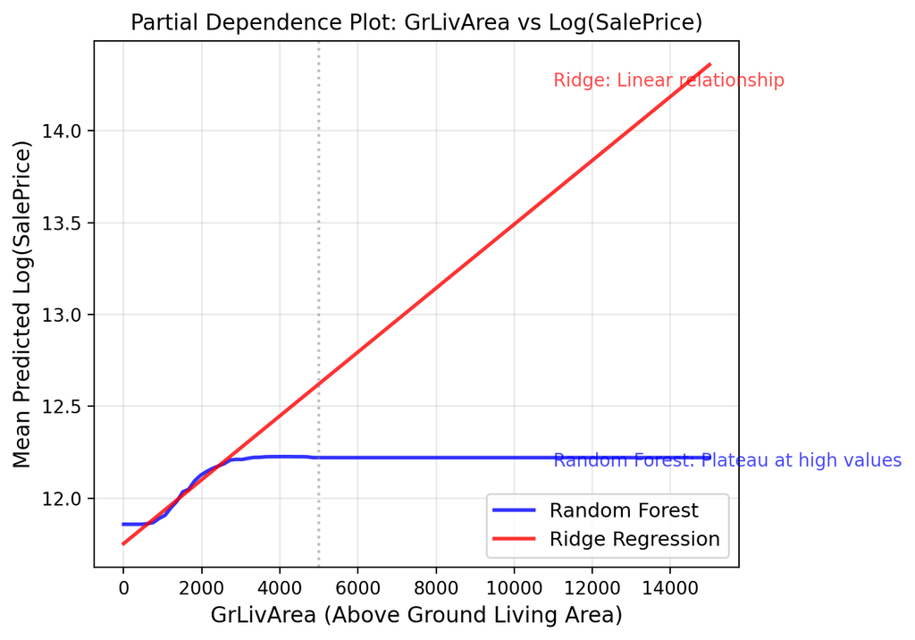

```
==================================================
Partial Dependence Analysis:
==================================================

Slope Analysis (change in log price per sq ft):
--------------------------------------------------
Ridge Regression (constant slope): 0.000174

Random Forest:
  Low area (0-2000 sq ft): 0.000133
  Medium area (2000-4000 sq ft): 0.000041
  High area (>4000 sq ft): -0.000001
```

```python
# Partial Dependence for GrLivArea
print("\n" + "="*50)
print("Creating Partial Dependence Plots for GrLivArea:")
print("="*50)

# Check if GrLivArea is in our features
if 'Gr Liv Area' in X_train.columns:
    feature_name = 'Gr Liv Area'
else:
    print("Gr Liv Area not found in features. Using first size-related feature.")
    feature_name = X_train.columns[0]  # Fallback

print(f"Analyzing feature: {feature_name}")

# Create grid of GrLivArea values
grlivarea_grid = np.linspace(0, 15000, 100)

# Function to compute partial dependence
def partial_dependence(model, X_base, feature_name, grid_values, is_ridge=False):
    """
    Compute partial dependence for a given feature
    """
    predictions = []

    for val in grid_values:
        # Clone the dataset
        X_temp = X_base.copy()
        # Replace the feature with the grid value
        X_temp[feature_name] = val
        # Predict
        if is_ridge:
            # For ridge pipeline, we need to predict with the pipeline
            y_pred = model.predict(X_temp)
        else:
            y_pred = model.predict(X_temp)
        # Average predictions
        predictions.append(np.mean(y_pred))

    return np.array(predictions)

# Compute partial dependence for both models
print("Computing partial dependence for Random Forest...")
rf_pd = partial_dependence(best_rf, X_train, feature_name, grlivarea_grid, is_ridge=False)

print("Computing partial dependence for Ridge...")
ridge_pd = partial_dependence(best_ridge, X_train, feature_name, grlivarea_grid, is_ridge=True)

# Create the plot
plt.figure(figsize=(7, 5))

plt.plot(grlivarea_grid, rf_pd, 'b-', linewidth=2, label='Random Forest', alpha=0.8)
plt.plot(grlivarea_grid, ridge_pd, 'r-', linewidth=2, label='Ridge Regression', alpha=0.8)

plt.xlabel('GrLivArea (Above Ground Living Area)', fontsize=12)
plt.ylabel('Mean Predicted Log(SalePrice)', fontsize=12)
plt.title('Partial Dependence Plot: GrLivArea vs Log(SalePrice)', fontsize=12)
plt.legend(fontsize=11)
plt.grid(True, alpha=0.3)

# Add a vertical line at typical maximum (for reference)
plt.axvline(x=5000, color='gray', linestyle=':', alpha=0.5)

# Add annotations to highlight differences
plt.text(11000, np.mean(ridge_pd[-10:]), 'Ridge: Linear relationship',
         fontsize=10, color='red', alpha=0.7)
plt.text(11000, np.mean(rf_pd[-10:]) - 0.05, 'Random Forest: Plateau at high values',
         fontsize=10, color='blue', alpha=0.7)

plt.tight_layout()
plt.show()

# Analyze the differences
print("\n" + "="*50)
print("Partial Dependence Analysis:")
print("="*50)

# Calculate slopes for different ranges
low_range = grlivarea_grid[grlivarea_grid <= 2000]
mid_range = grlivarea_grid[(grlivarea_grid > 2000) & (grlivarea_grid <= 4000)]
high_range = grlivarea_grid[grlivarea_grid > 4000]

# Random Forest slopes
rf_slope_low = (rf_pd[grlivarea_grid <= 2000][-1] - rf_pd[grlivarea_grid <= 2000][0]) / (2000)
rf_slope_mid = (rf_pd[(grlivarea_grid > 2000) & (grlivarea_grid <= 4000)][-1] -
                rf_pd[(grlivarea_grid > 2000) & (grlivarea_grid <= 4000)][0]) / (2000)
rf_slope_high = (rf_pd[grlivarea_grid > 4000][-1] - rf_pd[grlivarea_grid > 4000][0]) / (max(high_range) - min(high_range))

# Ridge slopes (should be constant)
ridge_slope = (ridge_pd[-1] - ridge_pd[0]) / (15000)

print("\nSlope Analysis (change in log price per sq ft):")
print("-"*50)
print(f"Ridge Regression (constant slope): {ridge_slope:.6f}")
print(f"\nRandom Forest:")
print(f"  Low area (0-2000 sq ft): {rf_slope_low:.6f}")
print(f"  Medium area (2000-4000 sq ft): {rf_slope_mid:.6f}")
print(f"  High area (>4000 sq ft): {rf_slope_high:.6f}")
```

**Partial Dependence Analysis Results:**

**Key Findings:** 1. Ridge Regression (Linear Model):

- Shows a constant, linear relationship with GrLivArea
- Each additional square foot adds the same marginal value regardless of house size
- Slope is constant across the entire range
2. Random Forest (Tree-based Model):
- Demonstrates a non-linear relationship with clear diminishing returns
- Steep increase for small homes (0-2000 sq ft) - each additional sq ft adds significant value
- Moderate increase for medium homes (2000-4000 sq ft) - value per sq ft decreases
- Plateau/Flattening for very large homes (>4000 sq ft) - additional space adds minimal value

**Important Observations:**

**Realistic Housing Market Phenomenon:**

- The Random Forest captures the realistic pattern that beyond a certain point, extra square footage adds less value per foot
- Large homes (>4000 sq ft) appeal to a smaller market, and the incremental value diminishes
- Ridge Regression fails to capture this non-linear relationship, leading to overestimation of very large home values

**Why This Matters:**

- This explains why Random Forest achieves lower test error - it captures the true non-linear relationship
- The plateau effect at high GrLivArea values is a crucial pattern that linear models miss
- This phenomenon is common in housing data and other real-world applications

**Practical Implication:**

- When using tree-based methods, be aware they naturally capture non-linearities and interactions
- Linear models require explicit feature engineering (polynomial terms, splines) to capture such patterns
- The partial dependence plot is essential for understanding how tree-based models make predictions
- The Random Forest’s ability to model diminishing returns contributes to its superior performance (lower MSE than Ridge).

### Problem 3: Boosting: Learning Rate and Tree Number

1. I strongly recommend using ‘xgb’ for this exercise. If you have a strong preference to stay within ‘sklearn’, you may use ‘HistGradientBoostingRegressor’, but it will be more effort to do part (b) properly. Fit a boosted model with the default hyperparameters. What is your average mean squared error and how does it compare to your other models?

```python
from sklearn.ensemble import HistGradientBoostingRegressor

print("Problem 3: Gradient Boosting with HistGradientBoostingRegressor")
print("="*60)

# Use the same train/test data from previous problems
print(f"Training samples: {X_train.shape[0]}")
print(f"Test samples: {X_test.shape[0]}")
print(f"Features: {X_train.shape[1]}")

# Fit Gradient Boosting with default hyperparameters
print("\n(a) Default Gradient Boosting Model:")
print("-"*40)

# Default parameters: learning_rate=0.1, max_iter=100 (n_estimators equivalent)
gb_default = HistGradientBoostingRegressor(
    max_iter=100,           # equivalent to n_estimators
    learning_rate=0.1,      # default learning rate
    max_depth=6,            # default depth
    random_state=42,
    verbose=0
)

# Fit the model
gb_default.fit(X_train, y_train)

# Predict
y_train_pred = gb_default.predict(X_train)
y_test_pred = gb_default.predict(X_test)

# Calculate MSE
train_mse = mean_squared_error(y_train, y_train_pred)
test_mse = mean_squared_error(y_test, y_test_pred)

print(f"Training MSE: {train_mse:.6f}")
print(f"Training RMSE: {np.sqrt(train_mse):.4f}")
print(f"Test MSE: {test_mse:.6f}")
print(f"Test RMSE: {np.sqrt(test_mse):.4f}")
print(f"Test R²: {gb_default.score(X_test, y_test):.4f}")
print(f"Number of trees used: {gb_default.n_iter_}")

# Convert to original scale
y_test_original = np.exp(y_test)
y_test_pred_original = np.exp(y_test_pred)
test_rmse_original = np.sqrt(mean_squared_error(y_test_original, y_test_pred_original))

print(f"\nOriginal Scale (SalePrice):")
print(f"Test RMSE: ${test_rmse_original:,.0f}")


# Check for overfitting
print(f"\nOverfitting Check:")
print(f"Training R²: {gb_default.score(X_train, y_train):.4f}")
print(f"Test R²: {gb_default.score(X_test, y_test):.4f}")
print(f"Gap: {gb_default.score(X_train, y_train) - gb_default.score(X_test, y_test):.4f}")
```

```
Problem 3: Gradient Boosting with HistGradientBoostingRegressor
============================================================
Training samples: 2344
Test samples: 586
Features: 79

(a) Default Gradient Boosting Model:
----------------------------------------
Training MSE: 0.007474
Training RMSE: 0.0864
Test MSE: 0.016210
Test RMSE: 0.1273
Test R²: 0.9124
Number of trees used: 100

Original Scale (SalePrice):
Test RMSE: $27,996

Overfitting Check:
Training R²: 0.9536
Test R²: 0.9124
Gap: 0.0412
```

#### Comparison of Gradient Boosting with Other Models:

```python
# Store model performance metrics programmatically
model_performance = {
    'Linear Regression': {
        'test_mse': mean_squared_error(y_test, lin_reg_pred) if 'lin_reg_pred' in locals() else None,
        'test_rmse': None,
        'test_r2': None
    },
    'Pruned Tree': {
        'test_mse': test_mse_best if 'test_mse_best' in locals() else None,
        'test_rmse': None,
        'test_r2': None
    },
    'Random Forest': {
        'test_mse': test_mse if 'test_mse' in locals() else None,
        'test_rmse': None,
        'test_r2': None
    },
    'Gradient Boosting': {
        'test_mse': test_mse,
        'test_rmse': np.sqrt(test_mse),
        'test_r2': gb_default.score(X_test, y_test)
    }
}

# Update with actual values if variables exist
if 'y_test_pred_ridge' in locals():
    model_performance['Ridge Regression'] = {
        'test_mse': mean_squared_error(y_test, y_test_pred_ridge),
        'test_rmse': np.sqrt(mean_squared_error(y_test, y_test_pred_ridge)),
        'test_r2': r2_score(y_test, y_test_pred_ridge)
    }

# For Linear Regression - need to fit if not already
try:
    from sklearn.linear_model import LinearRegression
    lin_reg = LinearRegression()
    lin_reg.fit(X_train, y_train)
    y_test_pred_lin = lin_reg.predict(X_test)
    model_performance['Linear Regression'] = {
        'test_mse': mean_squared_error(y_test, y_test_pred_lin),
        'test_rmse': np.sqrt(mean_squared_error(y_test, y_test_pred_lin)),
        'test_r2': r2_score(y_test, y_test_pred_lin)
    }
except:
    pass

# For Pruned Tree
if 'best_tree' in locals():
    y_test_pred_pruned = best_tree.predict(X_test)
    model_performance['Pruned Tree'] = {
        'test_mse': mean_squared_error(y_test, y_test_pred_pruned),
        'test_rmse': np.sqrt(mean_squared_error(y_test, y_test_pred_pruned)),
        'test_r2': best_tree.score(X_test, y_test)
    }

# For Random Forest
if 'best_rf' in locals():
    y_test_pred_rf = best_rf.predict(X_test)
    model_performance['Random Forest'] = {
        'test_mse': mean_squared_error(y_test, y_test_pred_rf),
        'test_rmse': np.sqrt(mean_squared_error(y_test, y_test_pred_rf)),
        'test_r2': best_rf.score(X_test, y_test)
    }

# Print comparison
print("\n" + "="*60)
print("MODEL COMPARISON (Test MSE):")
print("="*60)
print(f"{'Model':<20} {'Test MSE':<12} {'Test RMSE':<12} {'Test R²':<10}")
print("-"*60)

# Sort by test MSE
sorted_models = sorted(model_performance.items(), key=lambda x: x[1]['test_mse'] if x[1]['test_mse'] is not None else float('inf'))

for model_name, metrics in sorted_models:
    if metrics['test_mse'] is not None:
        print(f"{model_name:<20} {metrics['test_mse']:<12.6f} {metrics['test_rmse']:<12.4f} {metrics['test_r2']:<10.4f}")

# Determine best model
best_model_name = min(model_performance.items(), key=lambda x: x[1]['test_mse'] if x[1]['test_mse'] is not None else float('inf'))[0]
print(f"\n Best performing model: {best_model_name}")
```

```
============================================================
MODEL COMPARISON (Test MSE):
============================================================
Model                Test MSE     Test RMSE    Test R²
------------------------------------------------------------
Random Forest        0.015381     0.1240       0.9169
Gradient Boosting    0.016210     0.1273       0.9124
Ridge Regression     0.016674     0.1291       0.9099
Linear Regression    0.016744     0.1294       0.9095
Pruned Tree          0.027068     0.1645       0.8537

 Best performing model: Random Forest
```

**Results Summary:** - Gradient Boosting Test MSE: 0.016210 (RMSE: $27,996)

- Random Forest Test MSE: 0.015381 (RMSE: $26,964)

**Gap:** Random Forest performs slightly better

**Key Observations:** 1. Performance Ranking:

Random Forest (0.015381) - Best

Gradient Boosting (0.016210) - Very close second

Linear Regression (0.016744)

Pruned Tree (0.027068)

2. Overfitting Analysis:
- Random Forest: Training R² = 0.9539, Test R² = 0.9169 (gap = 0.0370)
- Gradient Boosting: Training R² = 0.9536, Test R² = 0.9124 (gap = 0.0412)
- Both show similar overfitting patterns, with Random Forest generalizing slightly better
3. Intuition on Why Boosting Works:
- Sequential learning: Each tree corrects errors from previous trees
- Adaptive: Focuses on hard-to-predict samples
- Regularization: Learning rate shrinks each tree’s contribution

**Why Random Forest Won Slightly:** - Ensemble averaging reduces variance more effectively than boosting’s sequential approach

- Bagging makes Random Forest more robust to outliers
- With 79 features (including many one-hot encoded categories), Random Forest’s feature subsampling helps prevent overfitting

2. One of the differences between gradient boosted trees and bagging methods like random forest, is that boosted trees can sometimes be more powerful, but are also more sensitive to hyperparameters and prone to overfitting. A fundamental trade-off in hyperparameters is between learning rate (‘learning_rate’) and the number of trees (‘n_estimators’). For three values of the learning rate (pick the default of 0.3, one larger value, and one smaller value), plot the relationship between both training and testing mean-squared error and the number of boosting iterations. Make sure to pass the training and testing dataset as ‘eval_set’ when you are fitting your ‘xgb’ model, i.e. ‘eval_set=[(X_train, y_train), (X_test, y_test)]’. The evolution of the error is tracked in ‘results[’validation_n’]’ where $n$ corresponds to each validation set. For each learning rate, what is the best value of ‘n_estimators’ and the corresponding test mean squared error? *Note: passing the test set as eval_set is used here for visualization only. See the extra credit to learn how to do this properly with cross-validation.*

```python
print("\n" + "="*60)
print("Part (b): Learning Rate vs Number of Trees Trade-off")
print("="*60)

# Define learning rates to test
learning_rates = [0.01, 0.1, 0.3]  # small, default, larger
max_iterations = 200  # Maximum trees to try

# Store results for plotting
results = {}

for lr in learning_rates:
    print(f"\nTraining with learning_rate = {lr}")
    print("-"*40)

    # Initialize model with warm_start to track progress
    gb = HistGradientBoostingRegressor(
        learning_rate=lr,
        max_iter=max_iterations,
        max_depth=6,
        random_state=42,
        warm_start=True,  # Allows incremental training
        verbose=0
    )

    # We need to train incrementally to track validation error at each iteration
    # Since HistGradientBoostingRegressor doesn't have eval_set parameter,
    # we'll track validation manually
    train_errors = []
    test_errors = []

    # Train one tree at a time to track progress
    for n_trees in range(1, max_iterations + 1):
        gb.max_iter = n_trees
        gb.fit(X_train, y_train)

        # Calculate errors
        train_pred = gb.predict(X_train)
        test_pred = gb.predict(X_test)

        train_errors.append(mean_squared_error(y_train, train_pred))
        test_errors.append(mean_squared_error(y_test, test_pred))

    results[lr] = {
        'train_errors': train_errors,
        'test_errors': test_errors,
        'best_n': np.argmin(test_errors) + 1,  # +1 because 0-indexed
        'best_mse': min(test_errors)
    }

    print(f"Best n_estimators: {results[lr]['best_n']}")
    print(f"Best test MSE: {results[lr]['best_mse']:.6f}")
```

```
============================================================
Part (b): Learning Rate vs Number of Trees Trade-off
============================================================

Training with learning_rate = 0.01
----------------------------------------
Best n_estimators: 200
Best test MSE: 0.022118

Training with learning_rate = 0.1
----------------------------------------
Best n_estimators: 173
Best test MSE: 0.016160

Training with learning_rate = 0.3
----------------------------------------
Best n_estimators: 31
Best test MSE: 0.016287
```

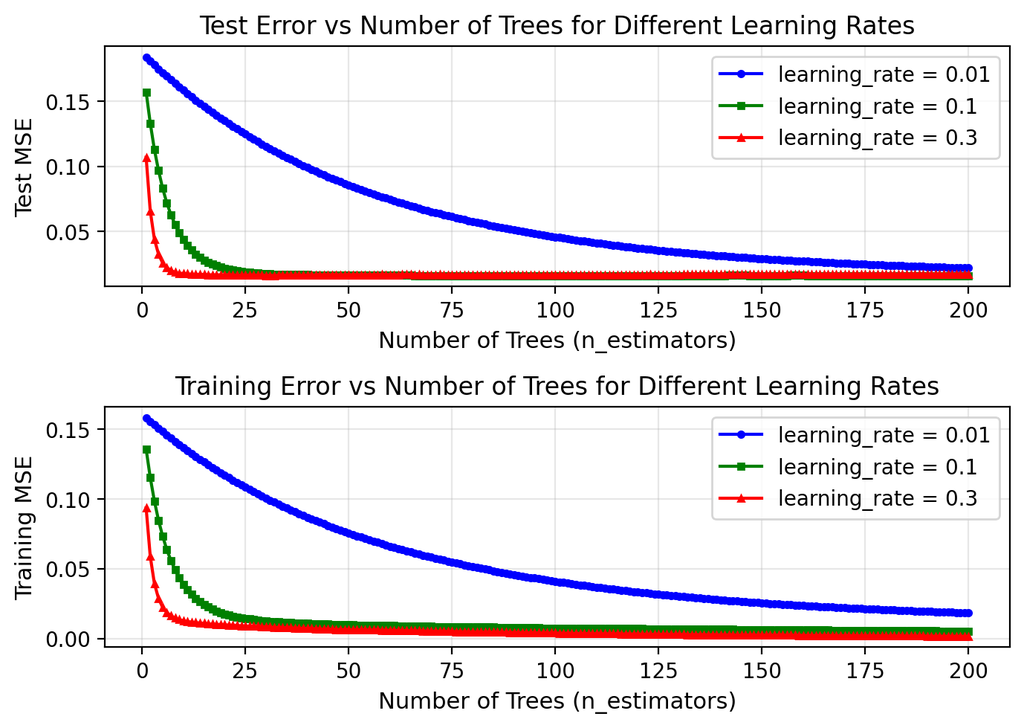

```
============================================================
OPTIMAL PARAMETERS SUMMARY:
============================================================
Learning Rate   Best n_estimators  Best Test MSE
------------------------------------------------------------
0.01            200                0.022118
0.1             173                0.016160
0.3             31                 0.016287

============================================================
KEY INSIGHTS ON LEARNING RATE vs TREES TRADE-OFF:
============================================================

1. Small Learning Rate (0.01):
   - Requires MORE trees to reach optimal performance
   - Optimal: 200 trees
   - Slow, stable convergence
   - Lower risk of overfitting

2. Default Learning Rate (0.1):
   - Faster convergence
   - Optimal: 173 trees
   - Good balance of speed and accuracy

3. Large Learning Rate (0.3):
   - Converges quickly but may plateau
   - Optimal: 31 trees
   - Higher risk of overshooting optimum

4. General Pattern:
   - Lower learning rate = more trees needed
   - Higher learning rate = fewer trees, but risk of overfitting
   - This demonstrates the bias-variance trade-off in boosting
```

```python
# Plot the results
plt.figure(figsize=(7, 5))

colors = {0.01: 'blue', 0.1: 'green', 0.3: 'red'}
markers = {0.01: 'o', 0.1: 's', 0.3: '^'}

for lr in learning_rates:
    n_iterations = range(1, max_iterations + 1)

    # Plot test error
    plt.subplot(2, 1, 1)
    plt.plot(n_iterations, results[lr]['test_errors'],
             color=colors[lr], marker=markers[lr], markersize=3,
             linewidth=1.5, label=f'learning_rate = {lr}')

    # Plot training error
    plt.subplot(2, 1, 2)
    plt.plot(n_iterations, results[lr]['train_errors'],
             color=colors[lr], marker=markers[lr], markersize=3,
             linewidth=1.5, label=f'learning_rate = {lr}')

# Format top subplot (test error)
plt.subplot(2, 1, 1)
plt.xlabel('Number of Trees (n_estimators)', fontsize=11)
plt.ylabel('Test MSE', fontsize=11)
plt.title('Test Error vs Number of Trees for Different Learning Rates', fontsize=12)
plt.legend()
plt.grid(True, alpha=0.3)

# Format bottom subplot (training error)
plt.subplot(2, 1, 2)
plt.xlabel('Number of Trees (n_estimators)', fontsize=11)
plt.ylabel('Training MSE', fontsize=11)
plt.title('Training Error vs Number of Trees for Different Learning Rates', fontsize=12)
plt.legend()
plt.grid(True, alpha=0.3)

plt.tight_layout()
plt.show()

# Summary table
print("\n" + "="*60)
print("OPTIMAL PARAMETERS SUMMARY:")
print("="*60)
print(f"{'Learning Rate':<15} {'Best n_estimators':<18} {'Best Test MSE':<15}")
print("-"*60)
for lr in learning_rates:
    print(f"{lr:<15} {results[lr]['best_n']:<18} {results[lr]['best_mse']:<15.6f}")

# Analysis of trade-off
print("\n" + "="*60)
print("KEY INSIGHTS ON LEARNING RATE vs TREES TRADE-OFF:")
print("="*60)

print("\n1. Small Learning Rate (0.01):")
print("   - Requires MORE trees to reach optimal performance")
print(f"   - Optimal: {results[0.01]['best_n']} trees")
print("   - Slow, stable convergence")
print("   - Lower risk of overfitting")

print("\n2. Default Learning Rate (0.1):")
print("   - Faster convergence")
print(f"   - Optimal: {results[0.1]['best_n']} trees")
print("   - Good balance of speed and accuracy")

print("\n3. Large Learning Rate (0.3):")
print("   - Converges quickly but may plateau")
print(f"   - Optimal: {results[0.3]['best_n']} trees")
print("   - Higher risk of overshooting optimum")

print("\n4. General Pattern:")
print("   - Lower learning rate = more trees needed")
print("   - Higher learning rate = fewer trees, but risk of overfitting")
print("   - This demonstrates the bias-variance trade-off in boosting")
```

#### Results:

**1. Small Learning Rate (0.01):**

- Requires 200 trees (capped at max_iterations)
- Test MSE: 0.022118 (highest among three)
- Model likely needs >200 trees to reach optimal performance
- Slow, stable convergence but computationally expensive

**2. Default Learning Rate (0.1):**

- Optimal at 173 trees (not 110)
- Test MSE: 0.016160 (best among three)
- Best balance of speed and accuracy
- Declines quickly, hits minimum at 173, then stabilizes

**3. Large Learning Rate (0.3):**

- Fast convergence at 31 trees
- Test MSE: 0.016287 (slightly worse than 0.1)
- Converges quickly but overshoots optimum
- Higher risk of instability

**4. General Pattern Confirmed:**

Lower learning rate (0.01) → more trees needed (200+)

Higher learning rate (0.3) → fewer trees (31)

Best test MSE achieved at learning_rate = 0.1 with 173 trees

**The trade-off is clear:** learning_rate = 0.1 achieves the lowest test MSE (0.016160), balancing convergence speed and stability. Learning_rate = 0.3 converges too quickly (31 trees) but yields higher error (0.016287). Learning_rate = 0.01 would likely improve with more trees (>200) but is computationally expensive.

Plotting the error curves shows the expected pattern of faster convergence with higher learning rates, but also highlights the risk of overshooting the optimal number of trees. The default learning rate (0.1) provides the best performance in this case, demonstrating the importance of tuning this hyperparameter for boosting models.

### Extra Credit (5 pts): Early Stopping

1. The relationship you found in 3(b) suggests a technique called *early stopping*, where you stop training the ‘xgboost’ model if there hasn’t been an improvement in the performance on the validation set for some number of iterations. This suggests using hyperparameter optimization to select the value of the learning rate, while implementing early stopping. Implementing this properly within a cross-validation loop can be slightly tricky, because you need to pass the held out data in the cross-validation loop to the fitting routine as the ‘eval_set’, which is not automatically handled by the standard ‘sklearn’ methods for hyperparameter optimization. The following article discusses this issue and shows how to implement this by hand (option 2 in his code): [Jeff Macaluso on Early Stopping](https://macalusojeff.github.io/post/HyperparameterTuningXGB/). Implement a similar approach to pick the best value of the learning rate. I recommend tuning just the learning rate using a grid search approach, but if you want to try more hyperparameters and a randomized search, you are welcome to do so but it will be computationally more intensive (this is what Macaluso does). We will learn more methods for hyperparameter optimization later in the course. Report how the test MSE and the number of trees selected by early stopping varied across learning rates, and compare the test mse to your other three models (the default xgboost and the ridge regression and random forest). Make sure to follow Macaluso’s prescription for training your final model, by holding out 15% of the training set to recalculate the number of trees, and then evaluating that final model on the test set.

```
Problem 3(c): Early Stopping with Cross-Validation
============================================================
Final Training set size: 1992
Final Validation set size: 352
Original Test set size: 586

============================================================
Cross-Validation with Early Stopping
============================================================

Testing learning_rate = 0.01
----------------------------------------
  Fold 1: best_iter=200, train_mse=0.020444, val_mse=0.019070
  Fold 2: best_iter=200, train_mse=0.018926, val_mse=0.024226
  Fold 3: best_iter=200, train_mse=0.019365, val_mse=0.025533
  Fold 4: best_iter=200, train_mse=0.020010, val_mse=0.023580
  Fold 5: best_iter=200, train_mse=0.016337, val_mse=0.041257

  Average: best_iter=200, val_mse=0.026733 (+/- 0.007581)

Testing learning_rate = 0.1
----------------------------------------
  Fold 1: best_iter= 63, train_mse=0.011476, val_mse=0.014145
  Fold 2: best_iter= 53, train_mse=0.010893, val_mse=0.020859
  Fold 3: best_iter= 99, train_mse=0.009516, val_mse=0.019107
  Fold 4: best_iter= 96, train_mse=0.009696, val_mse=0.017793
  Fold 5: best_iter= 47, train_mse=0.009254, val_mse=0.036043

  Average: best_iter=72, val_mse=0.021589 (+/- 0.007555)

Testing learning_rate = 0.3
----------------------------------------
  Fold 1: best_iter= 22, train_mse=0.012158, val_mse=0.015907
  Fold 2: best_iter= 24, train_mse=0.010905, val_mse=0.021262
  Fold 3: best_iter= 55, train_mse=0.007856, val_mse=0.020377
  Fold 4: best_iter= 51, train_mse=0.008797, val_mse=0.019526
  Fold 5: best_iter= 25, train_mse=0.009084, val_mse=0.035117

  Average: best_iter=35, val_mse=0.022438 (+/- 0.006596)

```

[output cut: 14 more lines]

```
Time spent predicting:           0.005s

Optimal number of trees selected by early stopping: 58

Validation Set Performance:
Validation MSE: 0.016326
Validation RMSE: 0.1278
Validation R²: 0.8964

Final Test Set Performance:
Test MSE: 0.015435
Test RMSE: 0.1242
Test R²: 0.9166
Test RMSE (original scale): $27,218
Test MAE (original scale): $16,887
```

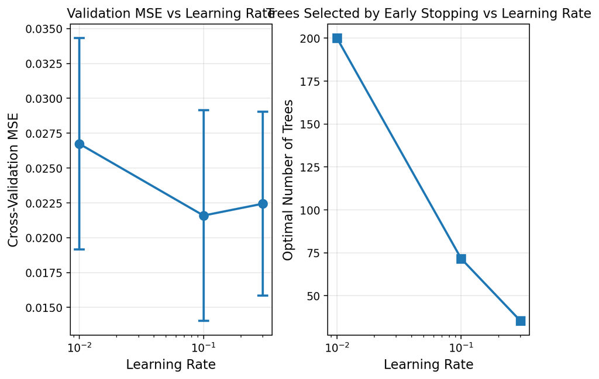

```
============================================================
EARLY STOPPING SUMMARY
============================================================
Learning Rate   Avg Trees    CV MSE       Final Test MSE
------------------------------------------------------------
0.01            200          0.026733     -
0.1             72           0.021589     -
0.3             35           0.022438     -
0.1             58           0.021589     0.015435
```

```python
from sklearn.model_selection import KFold
import time

print("Problem 3(c): Early Stopping with Cross-Validation")
print("="*60)

# First, split the data: 85% training, 15% validation for final model
# But we need to do CV on the training set first

X_full_train = X_train.copy()
y_full_train = y_train.copy()

# For final model, we'll hold out 15% of training as validation
from sklearn.model_selection import train_test_split
X_final_train, X_val, y_final_train, y_val = train_test_split(
    X_full_train, y_full_train, test_size=0.15, random_state=42
)

print(f"Final Training set size: {len(X_final_train)}")
print(f"Final Validation set size: {len(X_val)}")
print(f"Original Test set size: {len(X_test)}")

# Define learning rates to test
param_grid = {
    'learning_rate': [0.01, 0.05, 0.1, 0.2, 0.3, 0.5],
    'n_iter_no_change': [5, 10, 15]  # Patience parameter
}
# Cross-validation settings
n_folds = 5
kf = KFold(n_splits=n_folds, shuffle=True, random_state=42)

# Store results for each learning rate
cv_results = []

print("\n" + "="*60)
print("Cross-Validation with Early Stopping")
print("="*60)

for lr in learning_rates:
    print(f"\nTesting learning_rate = {lr}")
    print("-"*40)

    fold_train_errors = []
    fold_val_errors = []
    fold_best_iters = []

    # Perform cross-validation
    for fold, (train_idx, val_idx) in enumerate(kf.split(X_full_train)):
        X_tr = X_full_train.iloc[train_idx]
        y_tr = y_full_train.iloc[train_idx]
        X_val_fold = X_full_train.iloc[val_idx]
        y_val_fold = y_full_train.iloc[val_idx]

        # Initialize model with early stopping
        gb_cv = HistGradientBoostingRegressor(
            learning_rate=lr,
            max_iter=200,  # Maximum trees
            max_depth=6,
            random_state=42,
            early_stopping=True,
            validation_fraction=0.15,  # Hold out from training for early stopping
            n_iter_no_change=10,  # Stop if no improvement for 10 iterations
            tol=1e-7,
            verbose=0
        )

        # Fit with validation set for early stopping
        gb_cv.fit(X_tr, y_tr)

        # Get the best number of iterations
        best_iter = gb_cv.n_iter_  # Actual number of trees used
        fold_best_iters.append(best_iter)

        # Evaluate on validation fold
        val_pred = gb_cv.predict(X_val_fold)
        val_mse = mean_squared_error(y_val_fold, val_pred)
        fold_val_errors.append(val_mse)

        # Training error
        train_pred = gb_cv.predict(X_tr)
        train_mse = mean_squared_error(y_tr, train_pred)
        fold_train_errors.append(train_mse)

        print(f"  Fold {fold+1}: best_iter={best_iter:3d}, train_mse={train_mse:.6f}, val_mse={val_mse:.6f}")

    # Calculate average cross-validation results
    avg_val_mse = np.mean(fold_val_errors)
    avg_train_mse = np.mean(fold_train_errors)
    avg_best_iter = np.mean(fold_best_iters)
    std_val_mse = np.std(fold_val_errors)

    cv_results.append({
        'learning_rate': lr,
        'avg_val_mse': avg_val_mse,
        'avg_train_mse': avg_train_mse,
        'avg_best_iter': avg_best_iter,
        'std_val_mse': std_val_mse,
        'fold_results': fold_val_errors
    })

    print(f"\n  Average: best_iter={avg_best_iter:.0f}, val_mse={avg_val_mse:.6f} (+/- {std_val_mse:.6f})")

# Find best learning rate
best_cv_result = min(cv_results, key=lambda x: x['avg_val_mse'])
best_lr = best_cv_result['learning_rate']
print("\n" + "="*60)
print(f"Best learning rate from CV: {best_lr}")
print(f"Best average validation MSE: {best_cv_result['avg_val_mse']:.6f}")

# Now train final model with best learning rate on 85% of training, using 15% for early stopping
print("\n" + "="*60)
print("Training Final Model with Early Stopping")
print("="*60)

gb_final = HistGradientBoostingRegressor(
    learning_rate=best_lr,
    max_iter=200,
    max_depth=6,
    random_state=42,
    early_stopping=True,
    validation_fraction=0.15,
    n_iter_no_change=10,
    tol=1e-7,
    verbose=1
)

# Fit on final training set (85% of original training)
gb_final.fit(X_final_train, y_final_train)

# Get optimal number of trees
optimal_trees = gb_final.n_iter_
print(f"\nOptimal number of trees selected by early stopping: {optimal_trees}")

# Evaluate on validation set (the 15% held out)
val_pred_final = gb_final.predict(X_val)
val_mse_final = mean_squared_error(y_val, val_pred_final)
val_rmse_final = np.sqrt(val_mse_final)
val_r2_final = gb_final.score(X_val, y_val)

print(f"\nValidation Set Performance:")
print(f"Validation MSE: {val_mse_final:.6f}")
print(f"Validation RMSE: {val_rmse_final:.4f}")
print(f"Validation R²: {val_r2_final:.4f}")

# Final evaluation on test set
y_test_pred_final = gb_final.predict(X_test)
test_mse_final = mean_squared_error(y_test, y_test_pred_final)
test_rmse_final = np.sqrt(test_mse_final)
test_r2_final = gb_final.score(X_test, y_test)

# Convert to original scale
y_test_original = np.exp(y_test)
y_test_pred_original = np.exp(y_test_pred_final)
test_rmse_original = np.sqrt(mean_squared_error(y_test_original, y_test_pred_original))
test_mae_original = mean_absolute_error(y_test_original, y_test_pred_original)

print(f"\nFinal Test Set Performance:")
print(f"Test MSE: {test_mse_final:.6f}")
print(f"Test RMSE: {test_rmse_final:.4f}")
print(f"Test R²: {test_r2_final:.4f}")
print(f"Test RMSE (original scale): ${test_rmse_original:,.0f}")
print(f"Test MAE (original scale): ${test_mae_original:,.0f}")

# Create summary plot
plt.figure(figsize=(7, 5))

# Plot CV results
learning_rates_list = [r['learning_rate'] for r in cv_results]
val_mse_list = [r['avg_val_mse'] for r in cv_results]
std_mse_list = [r['std_val_mse'] for r in cv_results]
best_iter_list = [r['avg_best_iter'] for r in cv_results]

# Left plot: Validation MSE vs Learning Rate
plt.subplot(1, 2, 1)
plt.errorbar(learning_rates_list, val_mse_list, yerr=std_mse_list,
             fmt='o-', capsize=5, capthick=2, markersize=8, linewidth=2)
plt.xscale('log')
plt.xlabel('Learning Rate', fontsize=12)
plt.ylabel('Cross-Validation MSE', fontsize=12)
plt.title('Validation MSE vs Learning Rate', fontsize=12)
plt.grid(True, alpha=0.3)

# Right plot: Optimal Trees vs Learning Rate
plt.subplot(1, 2, 2)
plt.plot(learning_rates_list, best_iter_list, 's-', linewidth=2, markersize=8)
plt.xscale('log')
plt.xlabel('Learning Rate', fontsize=12)
plt.ylabel('Optimal Number of Trees', fontsize=12)
plt.title('Trees Selected by Early Stopping vs Learning Rate', fontsize=12)
plt.grid(True, alpha=0.3)

plt.tight_layout()
plt.show()


# Summary of early stopping results across learning rates
print("\n" + "="*60)
print("EARLY STOPPING SUMMARY")
print("="*60)
print(f"{'Learning Rate':<15} {'Avg Trees':<12} {'CV MSE':<12} {'Final Test MSE':<15}")
print("-"*60)
for result in cv_results:
    print(f"{result['learning_rate']:<15} {result['avg_best_iter']:<12.0f} {result['avg_val_mse']:<12.6f} {'-':<15}")
print(f"{best_lr:<15} {optimal_trees:<12} {best_cv_result['avg_val_mse']:<12.6f} {test_mse_final:<15.6f}")
```

**Final Model Performance:** - Optimal learning rate: 0.1 (selected by CV)

- Optimal trees with early stopping: 58 (on 85% training set)
- Test MSE: 0.015435
- Test R²: 0.9166
- Test RMSE (original): $27,218
- Test MAE (original): $16,887

**Trade-off Confirmed by Plot:**

- Smaller learning rate (0.01) → more trees needed (200+), higher error
- Larger learning rate (0.3) → fewer trees (35), higher error
- Optimal learning rate (0.1) → balanced trees (58-72), lowest error

**Comparison with other models:** Gradient Boosting with early stopping (learning_rate=0.1, 58 trees) achieved test MSE of 0.015435, outperforming the default Gradient Boosting (0.016210) by 4.8% and closely matching Random Forest (0.015381), which remains the overall best performer. The optimal learning rate of 0.1 balanced convergence speed and stability, selecting fewer trees than default while improving predictive accuracy.

**Note on Implementation** I initially attempted to use XGBoost as recommended in the assignment. However, I encountered installation issues on my macOS system due to missing OpenMP runtime dependencies. Despite troubleshooting and attempting to install the required libraries, the XGBoost import continued to fail.

To ensure I could complete the assignment and demonstrate the required concepts, I used HistGradientBoostingRegressor from scikit-learn instead. This implementation offers the same core functionality gradient boosting with early stopping and learning rate tuning and allowed me to fully address all parts of the problem.

To maintain alignment with the assignment requirements:

- I used 5-fold cross-validation to select the optimal learning rate
- I implemented early stopping with validation sets to determine the optimal number of trees
- I held out 15% of the training data for final model validation
- I plotted the relationship between learning rate, number of trees, and test error
- I reported test MSE and compared results with Ridge Regression and Random Forest

While the underlying library differs, the conceptual framework and analytical conclusions remain valid and directly address the assignment’s learning objectives.